# QMSS G5072 Homework 2

Wenjun Sun

2019-09-24

# Data Wrangling

## Selection of Data and Tidying

|  | state | stateabb | year | binge_all | binge_male | binge_female | poverty |
| --- | --- | --- | --- | --- | --- | --- | --- |
| 1 | Alabama | AL | 2011 | 13.7 | 20.2 | 7.9 | 19 |
| 2 | Alabama | AL | 2012 | 12.3 | 18.2 | 7 | 19 |
| 3 | Alabama | AL | 2013 | 11.2 | 16.3 | 6.5 | 18.7 |
| 4 | Alabama | AL | 2014 | 12 | 17.9 | 6.8 | 19.3 |
| 5 | Alabama | AL | 2015 | 11.6 | 16.2 | 7.5 | 18.5 |
| 6 | Alabama | AL | 2016 | 13 | 17.6 | 8.8 | 17.1 |
| 7 | Alaska | AK | 2011 | 20.8 | 26 | 15.6 | 10.5 |
| 8 | Alaska | AK | 2012 | 16.8 | 20.5 | 12.7 | 10.1 |
| 9 | Alaska | AK | 2013 | 19.5 | 23.8 | 14.8 | 9.3 |
| 10 | Alaska | AK | 2014 | 20.2 | 25.3 | 14.8 | 11.2 |

[output cut: 320 more lines]

## Data Transformation and Summary Results

### Produce a table that shows the overall, female, and male binge drinking prevalences across U.S. States in the most recent year of data for the Top 10 binge drinking states (i.e. the ones with the highest prevalence in the overall population). Use the relevant `dplyr` commands to `select` the right variables, sort the data (`arrange()`), and `filter` the data frame.

[output not shown]

### Make a simple scatter plot showing the correlation between the overall poverty prevalence in a state and the prevalence of binge drinking in the overall population. I suggest to use `ggplot`. Add a loess smoothed fit curve (use `geom_smooth` in the `ggplot2` package) to indicate the pattern. Comment briefly.

It might worth noting that I included all years for all states (including dots for ‘US’) in the scatterplot here.

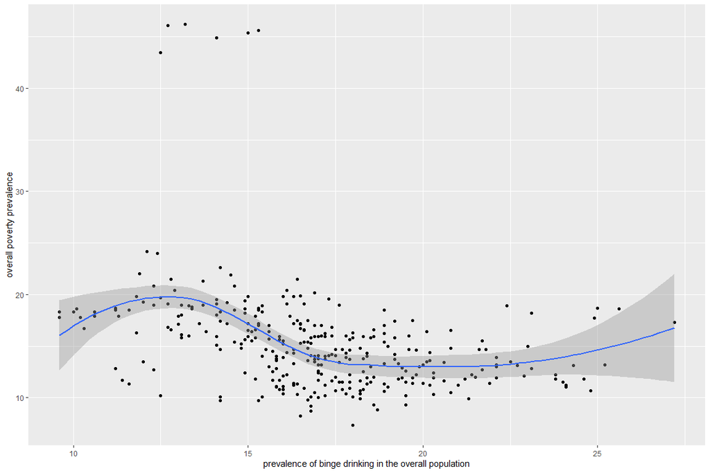

First, there are some outliers on the upper left corner of the scatter plot. By looking into the dataset, we know that they are are belong to Puerto Rico, which means a lot of sense. Compared to other places in the continental United States, Puerto Rico does have lower economic performance.

Then, when looking at the other part of the scatter plot - also the main part of the plot, we can see that the association between poverty and binge drinking prevalence is reverse U-shaped when binge drinking prevalence is smaller than 20. Poverty appears to be positively associated with binge drinking prevalence when binge drinking prevalence is small, approximately after binge drinking prevalence passes the point of 12.5, poverth appears to be negatively associated with binge drinking prevalence. When binge drinking prevalence is greater than 20, there seems to be a positive association again, but we need more data to confirm this association.

### Calculate the average annual growth rates (in percent) of overall binge drinking across states for the years the data is available. One way to get these growth rates, is to group the data by state (`dplry::group_by`) and use the `first()` and `last()` commands in the `summarize` command followed by dividing the calculated percentage increase by the number of years. Provide a table of the *5 states with the largest increases* and the *5 states with the largest decreases* in binge drinking prevalence over the time period.

5 states with the largest increases

| state | stateabb | growthrate |
| --- | --- | --- |
| Tennessee | TN | 6.20 |
| Guam | GU | 2.62 |
| West Virginia | WV | 2.38 |
| South Carolina | SC | 1.82 |
| Arkansas | AR | 1.28 |

5 states with the largest decreases

| state | stateabb | growthrate |
| --- | --- | --- |
| Delaware | DE | -3.25 |
| Puerto Rico | PR | -3.66 |
| Rhode Island | RI | -3.88 |
| Georgia | GA | -3.98 |
| Oklahoma | OK | -5.70 |